# Article Metadata Summaries

Toph Allen 4/9/2019

```r
terms <- read_lines("terms")

articles <- read_csv(here("data", "articles.csv")) %>%
  select(-X1, -id_types, -keywords)
id_types <- read_csv(here("data", "id_types.csv")) %>%
  select(-X1)
keywords <- read_csv(here("data", "keywords.csv")) %>%
  select(-X1)
text_matches <- read_csv(here("data", "text_matches.csv")) %>%
  select(-X1)
geonames <- read_csv(here("data", "geonames.csv")) %>%
  select(-X1)
subset <- read_csv(here("data", "subset.csv")) %>%
  select(-X1)
```

## Prevalence of Text Matches

Matching articles are a smallish subset of the total, 4.429%.

```r
ktable(articles$any_matches)
```

| Var1 | Freq |
| --- | --- |
| FALSE | 95571 |
| TRUE | 4429 |

```r
ktable(articles$text_matches) %>% scroll_box(height = "400px")
```

| Var1 | Freq |
| --- | --- |
| [‘field area’, ‘sampling site’, ‘sampling location’] | 1 |
| [‘field area’, ‘study area’] | 6 |
| [‘field area’, ‘study site’, ‘study area’] | 1 |
| [‘field area’, ‘study site’] | 4 |
| [‘field area’] | 59 |
| [‘field site’, ‘research site’] | 1 |
| [‘field site’, ‘sampling location’] | 3 |
| [‘field site’, ‘sampling site’, ‘sampling location’] | 2 |
| [‘field site’, ‘sampling site’] | 3 |
| [‘field site’, ‘study area’, ‘sampling location’] | 1 |
| [‘field site’, ‘study area’, ‘sampling site’] | 1 |
| [‘field site’, ‘study area’] | 13 |
| [‘field site’, ‘study location’, ‘sampling location’] | 1 |
| [‘field site’, ‘study site’, ‘research site’] | 2 |
| [‘field site’, ‘study site’, ‘sampling location’] | 1 |
| [‘field site’, ‘study site’, ‘sampling site’, ‘sampling area’] | 1 |
| [‘field site’, ‘study site’, ‘sampling site’, ‘sampling location’] | 2 |
| [‘field site’, ‘study site’, ‘study area’, ‘sampling site’, ‘sampling area’] | 2 |
| [‘field site’, ‘study site’, ‘study area’] | 11 |
| [‘field site’, ‘study site’, ‘study location’, ‘sampling site’] | 1 |
| [‘field site’, ‘study site’, ‘study location’] | 2 |
| [‘field site’, ‘study site’] | 22 |
| [‘field site’] | 79 |
| [‘field study’, ‘field area’, ‘study area’, ‘sampling site’] | 1 |
| [‘field study’, ‘field area’, ‘study area’] | 1 |
| [‘field study’, ‘field site’, ‘study area’] | 1 |
| [‘field study’, ‘field site’, ‘study site’, ‘research site’, ‘sampling location’] | 1 |
| [‘field study’, ‘field site’, ‘study site’, ‘research site’] | 1 |
| [‘field study’, ‘field site’, ‘study site’, ‘study area’] | 3 |
| [‘field study’, ‘field site’, ‘study site’] | 4 |

[output cut: 159 more lines]

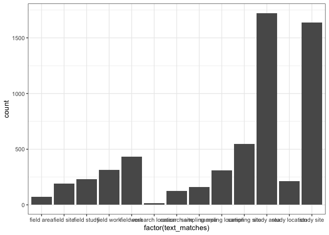

```r
text_matches %>%
  filter(!is.na(text_matches)) %>%
  ggplot(aes(x = factor(text_matches))) +
  geom_bar(stat = "count") +
  theme_bw()
```

## Examining characteristics of the subset

I pulled a few pieces of metadata for our subset of articles. These include:

- What type of article is it?
- Does it have a `<body>` tag?
- How long is it?
- Associated keywords
- What types of document identifiers does it have?

### Article types

There are many article types, but only a few which are widely used.

```r
articles %<>%
  mutate(article_type = fct_infreq(article_type))
ktable(articles$article_type) %>% scroll_box(height = "400px")
```

| Var1 | Freq |
| --- | --- |
| research-article | 72488 |
| review-article | 6790 |
| case-report | 4570 |
| other | 3619 |
| abstract | 2673 |
| brief-report | 1618 |
| letter | 1606 |
| editorial | 1516 |
| book-review | 1496 |
| correction | 1303 |
| article-commentary | 434 |
| news | 418 |
| meeting-report | 333 |
| discussion | 181 |
| protocol | 154 |
| obituary | 142 |
| product-review | 98 |
| rapid-communication | 94 |
| in-brief | 80 |
| reply | 74 |
| methods-article | 65 |
| retraction | 56 |
| systematic-review | 41 |
| data-paper | 39 |
| introduction | 36 |
| report | 18 |
| announcement | 17 |
| addendum | 14 |
| calendar | 10 |
| books-received | 5 |
| expression-of-concern | 5 |
| oration | 4 |
| index | 3 |

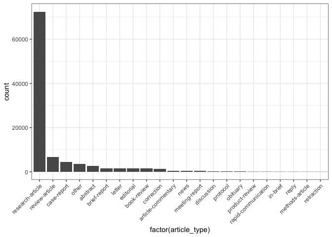

```r
articles %>%
  group_by(article_type) %>%
  mutate(n = n()) %>%
  filter(n > 50) %>%
  ungroup() %>%
  ggplot(aes(x = factor(article_type))) +
  geom_bar() +
  theme_bw() + theme(axis.text.x = element_text(angle = 45, hjust = 1))
```

Does the usage of these differ between the fieldwork subset?

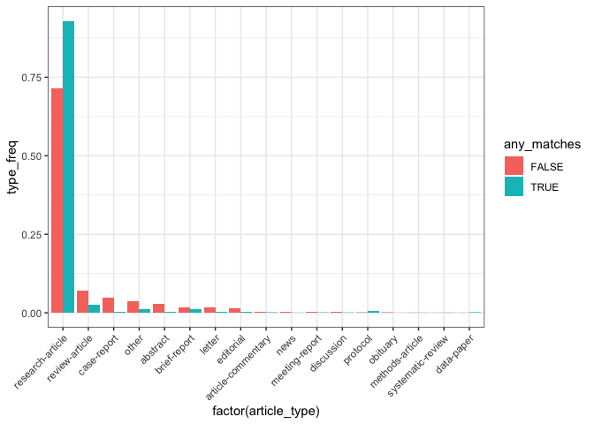

```r
articles %>%
  group_by(any_matches) %>%
  mutate(n_matches = n()) %>%
  group_by(any_matches, article_type) %>%
  summarize(type_freq = (n() / n_matches)[1]) %>%
  ungroup() %>%
  group_by(article_type) %>%
  filter(n() > 1) %>%
  ungroup() %>%
  ggplot(aes(x = factor(article_type), y = type_freq, fill = any_matches)) +
  geom_col(position = "dodge") +
  theme_bw() + theme(axis.text.x = element_text(angle = 45, hjust = 1))
```

There are more research articles, and fewer of everything else.

### Presence of `<body>` tag

```r
ktable(articles$has_body)
```

| Var1 | Freq |
| --- | --- |
| FALSE | 9078 |
| TRUE | 90922 |

```r
ktable(articles$article_type, articles$has_body) %>% scroll_box(height = "400px")
```

|  | FALSE | TRUE |
| --- | --- | --- |
| research-article | 4125 | 68363 |
| review-article | 226 | 6564 |
| case-report | 27 | 4543 |
| other | 2099 | 1520 |
| abstract | 543 | 2130 |
| brief-report | 28 | 1590 |
| letter | 283 | 1323 |
| editorial | 175 | 1341 |
| book-review | 989 | 507 |
| correction | 53 | 1250 |
| article-commentary | 6 | 428 |
| news | 174 | 244 |
| meeting-report | 195 | 138 |
| discussion | 4 | 177 |
| protocol | 0 | 154 |
| obituary | 125 | 17 |
| product-review | 0 | 98 |
| rapid-communication | 0 | 94 |
| in-brief | 2 | 78 |
| reply | 10 | 64 |
| methods-article | 0 | 65 |
| retraction | 0 | 56 |
| systematic-review | 0 | 41 |
| data-paper | 0 | 39 |
| introduction | 4 | 32 |
| report | 0 | 18 |
| announcement | 0 | 17 |
| addendum | 0 | 14 |
| calendar | 4 | 6 |
| books-received | 0 | 5 |
| expression-of-concern | 0 | 5 |
| oration | 3 | 1 |
| index | 3 | 0 |

### Length

```r
types <- articles %>%
  group_by(any_matches) %>%
  mutate(match_n = n()) %>%
  group_by(article_type) %>%
  mutate(type_n = n()) %>%
  group_by(any_matches, article_type) %>%
  summarize(match_x_type = n(),
            match_n = match_n[1],
            type_n = type_n[1]) %>%
  ungroup() %>%
  mutate(x_over_match = match_x_type / match_n,
         x_over_type = match_x_type / type_n)

type_filter <- types %>%
  filter(x_over_match > 0.005) %>%
  group_by(article_type) %>%
  filter(n() > 1) %>%
  pull(article_type) %>%
  unique()
```

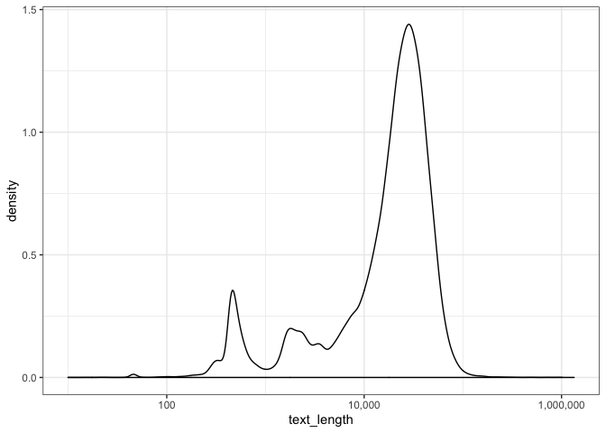

```r
ggplot(articles, aes(x = text_length)) +
  geom_density() +
  scale_x_log10(labels = comma) +
  theme_bw()
```

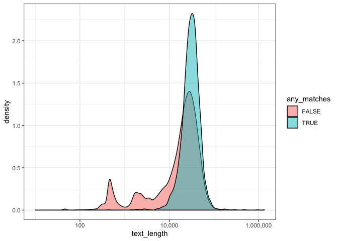

```r
ggplot(articles, aes(x = text_length, fill = any_matches)) +
  geom_density(alpha = 0.5) +
  scale_x_log10(labels = comma) +
  theme_bw()
```

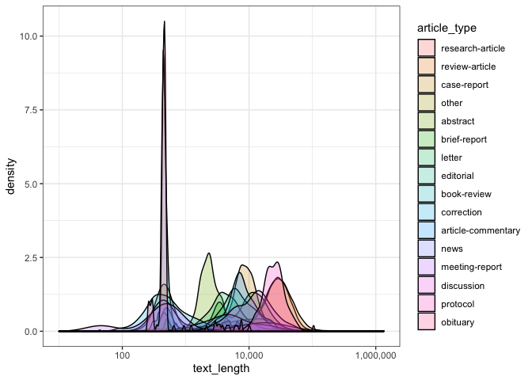

```r
articles %>%
  group_by(article_type) %>%
  filter(n() > 100) %>%
  ggplot(aes(x = text_length, fill = article_type)) +
  geom_density(alpha = 0.25) +
  scale_x_log10(labels = comma) +
  theme_bw()
```

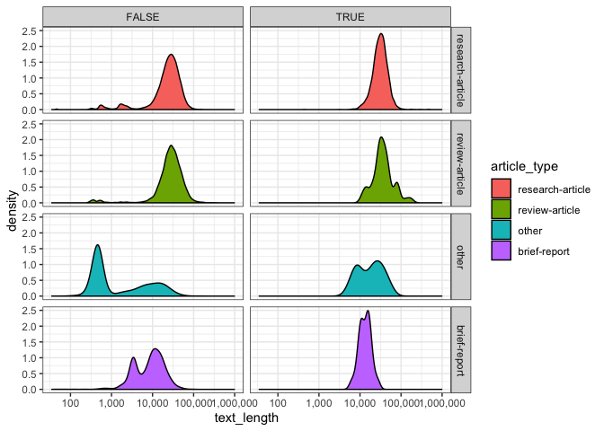

```r
articles %>%
  filter(article_type %in% type_filter) %>%
  ggplot(aes(x = text_length, fill = article_type)) +
  geom_density() +
  scale_x_log10(labels = comma) +
  facet_grid(article_type ~ any_matches) +
  theme_bw()
```

### Usage of Keywords

```r
keywords_per_paper <- keywords %>%
  group_by(id) %>%
  summarize(any_matches = unique(any_matches),
            n = n())
```

A total of 51182 papers out of 100000 (51.182%) had keywords.

For those matching fieldwork terms:

```r
k <- keywords_per_paper %>%
  filter(any_matches == TRUE) %>%
  nrow()
nk <- articles %>%
  filter(any_matches == TRUE) %>%
  nrow()

k / nk * 100
```

```
## [1] 57.66539
```

For those not matching fieldwork terms:

```r
k <- keywords_per_paper %>%
  filter(any_matches == FALSE) %>%
  nrow()
nk <- articles %>%
  filter(any_matches == FALSE) %>%
  nrow()

k / nk * 100
```

```
## [1] 50.88154
```

These are the top twenty-five keywords used in all documents:

```r
keyword_summary <- keywords %>%
  group_by(keywords) %>%
  summarize(n = n()) %>%
  arrange(-n) %>%
  head(25)

knitr::kable(keyword_summary) %>%
  kable_styling(bootstrap_options = c("hover", "condensed", "responsive"),
                full_width = FALSE,
                position = "left") %>%
  scroll_box(height = "400px")
```

| keywords | n |
| --- | --- |
| apoptosis | 377 |
| inflammation | 342 |
| breast cancer | 314 |
| cancer | 313 |
| HIV | 299 |
| prognosis | 257 |
| Breast cancer | 245 |
| obesity | 244 |
| Epidemiology | 236 |
| epidemiology | 219 |
| oxidative stress | 219 |
| meta-analysis | 216 |
| Obesity | 214 |
| Inflammation | 209 |
| children | 196 |
| aging | 190 |
| depression | 186 |
| colorectal cancer | 182 |
| Cancer | 174 |
| Children | 174 |
| Alzheimer’s disease | 172 |
| Apoptosis | 171 |
| metastasis | 165 |
| Prognosis | 165 |
| Iran | 158 |

For those matching fieldwork terms:

```r
fw_keyword_summary <- keywords %>%
  filter(any_matches == TRUE) %>%
  group_by(keywords) %>%
  summarize(n = n()) %>%
  arrange(-n) %>%
  head(25)

knitr::kable(fw_keyword_summary) %>%
  kable_styling(bootstrap_options = c("hover", "condensed", "responsive"),
                full_width = FALSE,
                position = "left") %>%
  scroll_box(height = "400px")
```

| keywords | n |
| --- | --- |
| Malaria | 64 |
| Ethiopia | 40 |
| HIV | 39 |
| epidemiology | 34 |
| Plasmodium falciparum | 31 |
| Epidemiology | 30 |
| India | 27 |
| Iran | 24 |
| South Africa | 23 |
| Kenya | 21 |
| malaria | 21 |
| Prevalence | 21 |
| Tanzania | 21 |
| Children | 20 |
| Nigeria | 20 |
| Africa | 19 |
| China | 18 |
| Bangladesh | 16 |
| Mental health | 16 |
| Pregnancy | 16 |
| taxonomy | 16 |
| Adolescents | 15 |
| children | 15 |
| Depression | 15 |
| GIS | 15 |

And those with no matches for fieldwork terms:

```r
nofw_keyword_summary <- keywords %>%
  filter(any_matches == FALSE) %>%
  group_by(keywords) %>%
  summarize(n = n()) %>%
  arrange(-n) %>%
  head(25)

knitr::kable(nofw_keyword_summary) %>%
  kable_styling(bootstrap_options = c("hover", "condensed", "responsive"),
                full_width = FALSE,
                position = "left") %>%
  scroll_box(height = "400px")
```

| keywords | n |
| --- | --- |
| apoptosis | 376 |
| inflammation | 339 |
| breast cancer | 310 |
| cancer | 310 |
| HIV | 260 |
| prognosis | 256 |
| Breast cancer | 240 |
| obesity | 231 |
| oxidative stress | 218 |
| Inflammation | 207 |
| Epidemiology | 206 |
| Obesity | 204 |
| meta-analysis | 203 |
| aging | 188 |
| epidemiology | 185 |
| children | 181 |
| colorectal cancer | 180 |
| depression | 178 |
| Apoptosis | 171 |
| Alzheimer’s disease | 169 |
| Cancer | 169 |
| metastasis | 165 |
| Prognosis | 161 |
| Children | 154 |
| prostate cancer | 153 |

And per fieldwork term:

```r
kwd_x_match <- keywords %>%
  left_join(select(articles, id, text_matches), by = "id") %>%
  mutate(text_matches = replace_na(text_matches, ""))

for (term in terms) {
  print(paste("Term: ", term))
  kwd_x_match %>%
    filter(map_lgl(kwd_x_match$text_matches, ~str_detect(.x, fixed(term)))) %>%
    group_by(keywords) %>%
    summarize(n = n()) %>%
    arrange(desc(n)) %>%
    print()
}
```

```
## [1] "Term:  field work"
## # A tibble: 956 x 2
##    keywords         n
##    <chr>        <int>
##  1 India            6
##  2 Malaria          6
##  3 Bangladesh       5
##  4 Kenya            5
##  5 taxonomy         4
##  6 Africa           3
##  7 epidemiology     3
##  8 Epidemiology     3
##  9 HIV              3
## 10 rural            3
## # … with 946 more rows
```

[output cut: 180 more lines]

## GeoNames

It looks like articles that match the fieldwork terms have many more geonames in them than those that don’t.

```r
summary(geonames)
```

```
##     n_spans        n_spans_over90  text_matches       any_matches
##  Min.   :   0.00   Min.   :  0.0   Length:2000        Mode :logical
##  1st Qu.:   4.00   1st Qu.:  1.0   Class :character   FALSE:1000
##  Median :  14.00   Median :  4.0   Mode  :character   TRUE :1000
##  Mean   :  29.55   Mean   : 11.6
##  3rd Qu.:  33.00   3rd Qu.: 12.0
##  Max.   :2448.00   Max.   :680.0
```

```r
geonames %>% filter(any_matches == TRUE) %>% summary
```

```
##     n_spans        n_spans_over90   text_matches       any_matches
##  Min.   :   0.00   Min.   :  0.00   Length:1000        Mode:logical
##  1st Qu.:  13.00   1st Qu.:  3.00   Class :character   TRUE:1000
##  Median :  27.00   Median :  9.00   Mode  :character
##  Mean   :  47.68   Mean   : 18.46
##  3rd Qu.:  53.25   3rd Qu.: 20.00
##  Max.   :2448.00   Max.   :680.00
```

```r
geonames %>% filter(any_matches == FALSE) %>% summary
```

```
##     n_spans       n_spans_over90    text_matches       any_matches
##  Min.   :  0.00   Min.   :  0.000   Length:1000        Mode :logical
##  1st Qu.:  1.00   1st Qu.:  0.000   Class :character   FALSE:1000
##  Median :  6.00   Median :  1.000   Mode  :character
##  Mean   : 11.43   Mean   :  4.743
##  3rd Qu.: 14.00   3rd Qu.:  5.000
##  Max.   :240.00   Max.   :211.000
```

## Subset

We’re going to take a brief look at the distribution of GeoNames and text length in the subset.

```r
summary(subset)
```

```
##       _id              length         n_geospans
##  Min.   :  59655   Min.   :  3157   Min.   :   0.00
##  1st Qu.:3812252   1st Qu.: 24110   1st Qu.:  14.00
##  Median :4731496   Median : 31304   Median :  27.00
##  Mean   :4658743   Mean   : 33630   Mean   :  44.98
##  3rd Qu.:5637197   3rd Qu.: 39958   3rd Qu.:  51.00
##  Max.   :6436149   Max.   :483805   Max.   :4313.00
```

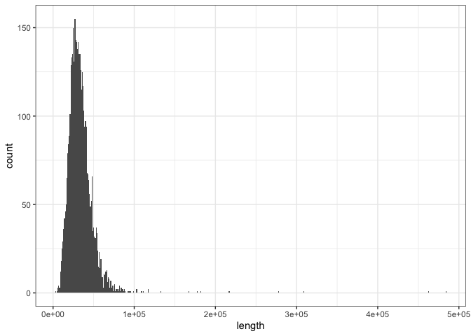

```r
ggplot(subset, aes(x = length)) +
  geom_histogram(binwidth = 1000) +
  theme_bw()
```

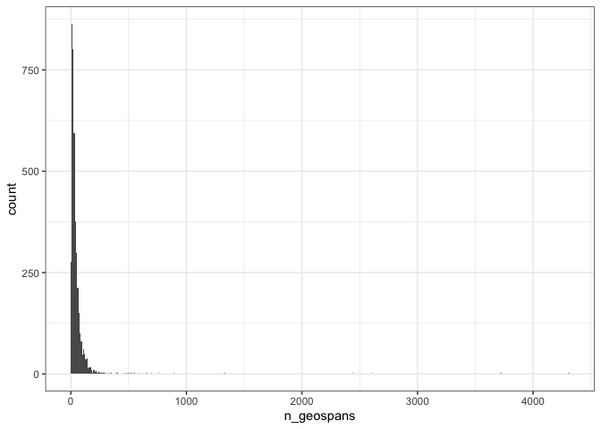

```r
ggplot(subset, aes(x = n_geospans)) +
  geom_histogram(binwidth = 10) +
  theme_bw()
```

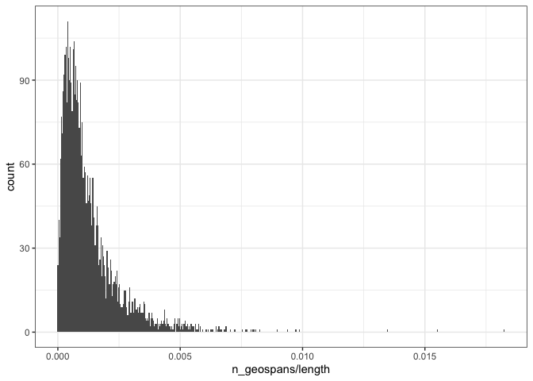

```r
ggplot(subset, aes(x = n_geospans / length)) +
  geom_histogram(bins = 500) +
  theme_bw()
```

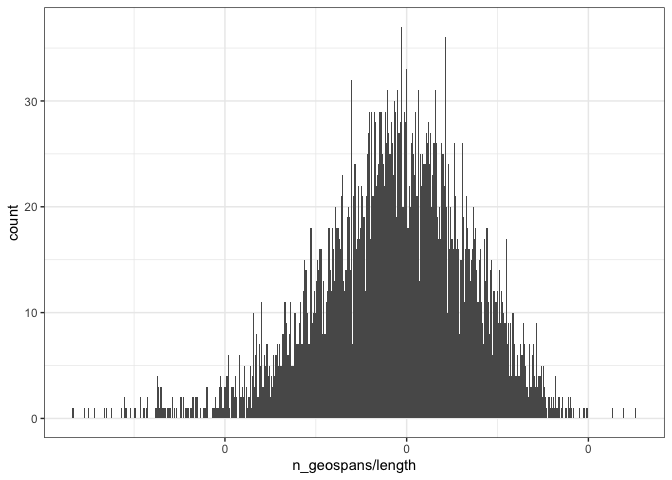

```r
ggplot(subset, aes(x = n_geospans / length)) +
  geom_histogram(bins = 500) +
  scale_x_log10(labels = comma) +
  theme_bw()
```

```r
deciles = seq(0, 1, 0.1)
quantile(subset$length, probs = deciles)
```

```
##       0%      10%      20%      30%      40%      50%      60%      70%
##   3157.0  18483.6  22546.0  25457.9  28384.2  31304.0  34373.4  37878.4
##      80%      90%     100%
##  42443.6  50066.5 483805.0
```

```r
quantile(subset$n_geospans, probs = deciles)
```

```
##     0%    10%    20%    30%    40%    50%    60%    70%    80%    90%
##    0.0    7.0   12.0   17.0   22.0   27.0   34.0   44.7   59.0   88.0
##   100%
## 4313.0
```

```r
quantiles = c(0.05, 0.25, 0.5, 0.75, 0.95)
quantile(subset$length, probs = quantiles)
```

```
##       5%      25%      50%      75%      95%
## 15178.35 24110.00 31304.00 39958.25 56775.05
```

```r
quantile(subset$n_geospans, probs = quantiles)
```

```
##  5% 25% 50% 75% 95%
##   4  14  27  51 124
```

```r
percentiles = seq(0, 1, 0.01)
quantile(subset$length, probs = percentiles)
```

```
##        0%        1%        2%        3%        4%        5%        6%
##   3157.00  10474.29  11987.74  13345.44  14351.88  15178.35  16128.62
##        7%        8%        9%       10%       11%       12%       13%
##  16842.49  17413.08  17956.59  18483.60  18986.10  19489.32  19847.59
##       14%       15%       16%       17%       18%       19%       20%
##  20361.78  20777.80  21137.56  21626.44  21915.98  22237.99  22546.00
##       21%       22%       23%       24%       25%       26%       27%
##  22900.93  23178.52  23452.77  23818.60  24110.00  24387.72  24703.97
##       28%       29%       30%       31%       32%       33%       34%
##  24983.24  25178.19  25457.90  25823.82  26122.52  26382.30  26689.22
##       35%       36%       37%       38%       39%       40%       41%
##  26911.85  27220.84  27505.07  27803.18  28051.77  28384.20  28667.67
##       42%       43%       44%       45%       46%       47%       48%
##  28987.58  29222.00  29546.52  29835.80  30051.30  30353.36  30678.28
##       49%       50%       51%       52%       53%       54%       55%
##  31029.78  31304.00  31606.37  31885.48  32135.75  32485.94  32791.55
##       56%       57%       58%       59%       60%       61%       62%
##  33047.92  33381.54  33696.42  34077.47  34373.40  34726.07  35068.64
##       63%       64%       65%       66%       67%       68%       69%
##  35440.74  35798.16  36114.05  36452.04  36787.74  37166.08  37470.54
##       70%       71%       72%       73%       74%       75%       76%
##  37878.40  38226.62  38680.72  39047.42  39616.98  39958.25  40341.44
##       77%       78%       79%       80%       81%       82%       83%
##  40804.88  41305.40  41848.07  42443.60  43027.21  43668.12  44297.78
##       84%       85%       86%       87%       88%       89%       90%
##  45029.24  45755.40  46603.32  47295.55  48019.76  48931.11  50066.50
##       91%       92%       93%       94%       95%       96%       97%
##  50960.05  52469.96  53623.65  54817.54  56775.05  59333.20  64293.78
##       98%       99%      100%
##  68171.26  79112.45 483805.00
```

```r
quantile(subset$n_geospans, probs = percentiles)
```

```
##      0%      1%      2%      3%      4%      5%      6%      7%      8%
##    0.00    1.00    2.00    3.00    4.00    4.00    5.00    6.00    6.00
##      9%     10%     11%     12%     13%     14%     15%     16%     17%
##    7.00    7.00    8.00    8.00    9.00    9.00   10.00   10.00   11.00
##     18%     19%     20%     21%     22%     23%     24%     25%     26%
##   11.00   11.00   12.00   12.00   13.00   13.00   14.00   14.00   15.00
##     27%     28%     29%     30%     31%     32%     33%     34%     35%
##   15.00   16.00   16.00   17.00   17.00   18.00   18.00   19.00   19.00
##     36%     37%     38%     39%     40%     41%     42%     43%     44%
##   20.00   20.00   21.00   21.00   22.00   22.00   23.00   23.00   24.00
##     45%     46%     47%     48%     49%     50%     51%     52%     53%
##   24.00   25.00   25.00   26.00   27.00   27.00   28.00   28.00   29.00
##     54%     55%     56%     57%     58%     59%     60%     61%     62%
##   30.00   30.05   31.00   32.00   33.00   34.00   34.00   35.00   36.00
##     63%     64%     65%     66%     67%     68%     69%     70%     71%
##   37.00   38.00   39.00   39.00   40.00   42.00   43.00   44.70   46.00
##     72%     73%     74%     75%     76%     77%     78%     79%     80%
##   47.00   48.00   49.14   51.00   52.00   54.00   55.58   57.00   59.00
##     81%     82%     83%     84%     85%     86%     87%     88%     89%
##   61.00   63.00   65.00   67.00   70.00   73.00   76.57   80.00   84.79
##     90%     91%     92%     93%     94%     95%     96%     97%     98%
##   88.00   94.01  101.12  110.00  116.00  124.00  136.00  148.67  171.78
##     99%    100%
##  234.89 4313.00
```

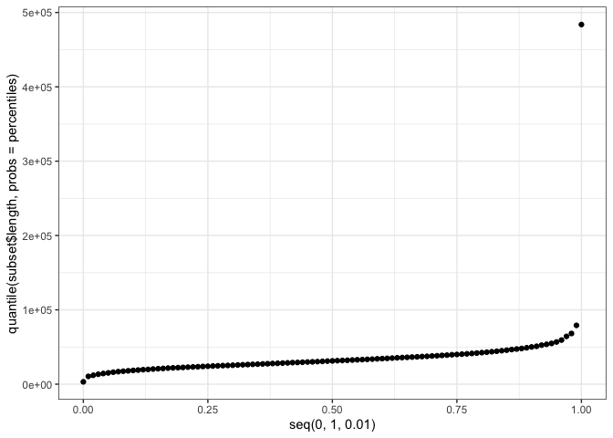

```r
qplot(seq(0, 1, 0.01), quantile(subset$length, probs = percentiles)) + theme_bw()
```

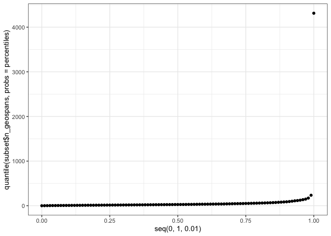

```r
qplot(seq(0, 1, 0.01), quantile(subset$n_geospans, probs = percentiles)) + theme_bw()
```

### Density

I will also consider subsetting on `n_geospans / length`.

```r
subset <- subset %>%
  filter(n_geospans > 0) %>%
  mutate(density = n_geospans / length,
         log_density = log(density))

mean(subset$log_density)
```

```
## [1] -7.063298
```

```r
sd(subset$log_density)
```

```
## [1] 0.9587384
```

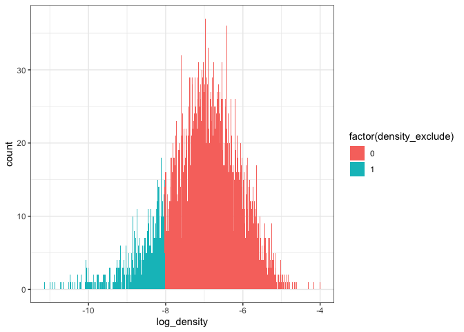

```r
subset <- subset %>%
  mutate(density_exclude = ifelse(log_density < mean(log_density) - sd(log_density), 1, 0),
         density_excludem = ifelse(log_density < median(log_density), 1, 0))

ggplot(subset, aes(x = log_density)) +
  geom_histogram(bins = 500, aes(fill = factor(density_exclude))) +
  theme_bw()
```

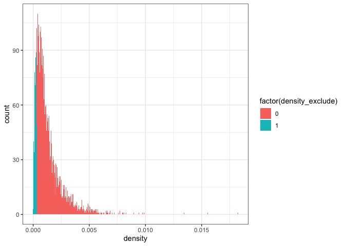

```r
ggplot(subset, aes(x = density)) +
  geom_histogram(bins = 500, aes(fill = factor(density_exclude))) +
  theme_bw()
```

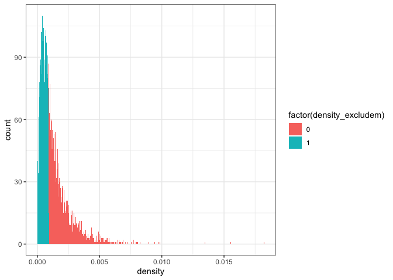

```r
ggplot(subset, aes(x = density)) +
  geom_histogram(bins = 500, aes(fill = factor(density_excludem))) +
  theme_bw()
```

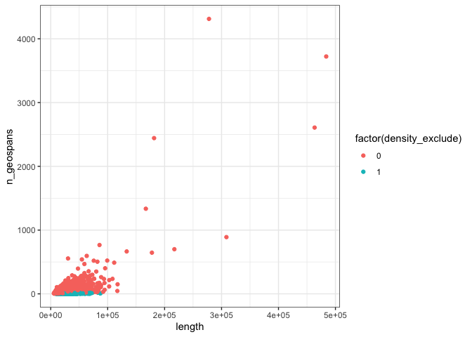

```r
ggplot(subset, aes(x = length, y = n_geospans, color = factor(density_exclude))) +
  geom_point() +
  theme_bw()
```

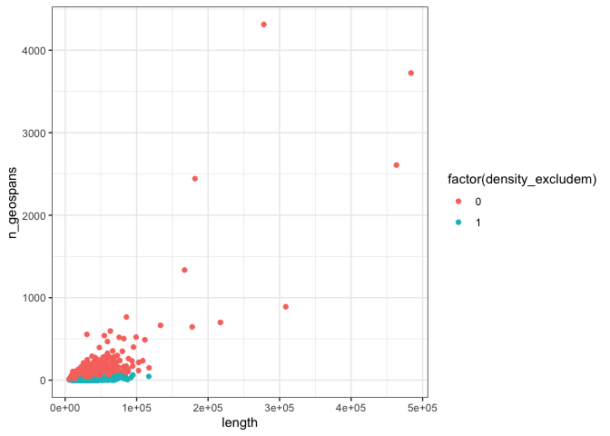

```r
ggplot(subset, aes(x = length, y = n_geospans, color = factor(density_excludem))) +
  geom_point() +
  theme_bw()
```

```r
subset %>%
  filter(density_exclude == 1) %>%
  summary()
```

```
##       _id              length        n_geospans        density
##  Min.   : 115849   Min.   : 9367   Min.   : 1.000   Min.   :1.456e-05
##  1st Qu.:3836758   1st Qu.:26074   1st Qu.: 4.000   1st Qu.:1.399e-04
##  Median :4764600   Median :33144   Median : 7.000   Median :2.101e-04
##  Mean   :4709862   Mean   :35183   Mean   : 6.928   Mean   :1.992e-04
##  3rd Qu.:5714953   3rd Qu.:41631   3rd Qu.: 9.000   3rd Qu.:2.738e-04
##  Max.   :6428738   Max.   :87262   Max.   :21.000   Max.   :3.279e-04
##   log_density      density_exclude density_excludem
##  Min.   :-11.137   Min.   :1       Min.   :1
##  1st Qu.: -8.874   1st Qu.:1       1st Qu.:1
##  Median : -8.468   Median :1       Median :1
##  Mean   : -8.658   Mean   :1       Mean   :1
##  3rd Qu.: -8.203   3rd Qu.:1       3rd Qu.:1
##  Max.   : -8.023   Max.   :1       Max.   :1
```

```r
subset %>%
  filter(density_exclude == 0) %>%
  summary()
```

```
##       _id              length         n_geospans         density
##  Min.   :  59655   Min.   :  5434   Min.   :   3.00   Min.   :0.0003284
##  1st Qu.:3810636   1st Qu.: 23787   1st Qu.:  20.00   1st Qu.:0.0006631
##  Median :4727902   Median : 30989   Median :  33.00   Median :0.0010684
##  Mean   :4648982   Mean   : 33392   Mean   :  51.96   Mean   :0.0014746
##  3rd Qu.:5620660   3rd Qu.: 39715   3rd Qu.:  57.00   3rd Qu.:0.0018300
##  Max.   :6436149   Max.   :483805   Max.   :4313.00   Max.   :0.0182470
##   log_density     density_exclude density_excludem
##  Min.   :-8.021   Min.   :0       Min.   :0.0000
##  1st Qu.:-7.319   1st Qu.:0       1st Qu.:0.0000
##  Median :-6.842   Median :0       Median :0.0000
##  Mean   :-6.782   Mean   :0       Mean   :0.4117
##  3rd Qu.:-6.303   3rd Qu.:0       3rd Qu.:1.0000
##  Max.   :-4.004   Max.   :0       Max.   :1.0000
```

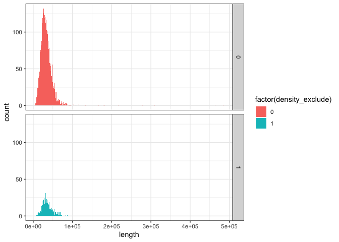

```r
# Plot of density exclusion

ggplot(subset, aes(x = length, fill = factor(density_exclude))) +
  geom_histogram(binwidth = 1000) +
  facet_grid(density_exclude~.) +
  theme_bw()
```

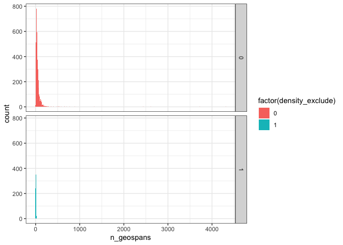

```r
ggplot(subset, aes(x = n_geospans, fill = factor(density_exclude))) +
  geom_histogram(binwidth = 10) +
  facet_grid(density_exclude~.) +
  theme_bw()
```

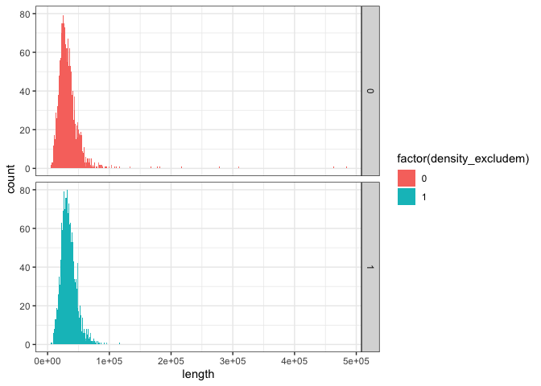

```r
ggplot(subset, aes(x = length, fill = factor(density_excludem))) +
  geom_histogram(binwidth = 1000) +
  facet_grid(density_excludem~.) +
  theme_bw()
```

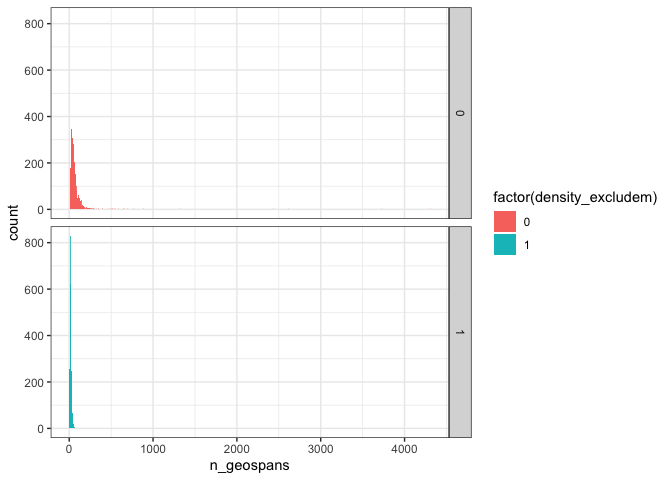

```r
ggplot(subset, aes(x = n_geospans, fill = factor(density_excludem))) +
  geom_histogram(binwidth = 10) +
  facet_grid(density_excludem~.) +
  theme_bw()
```

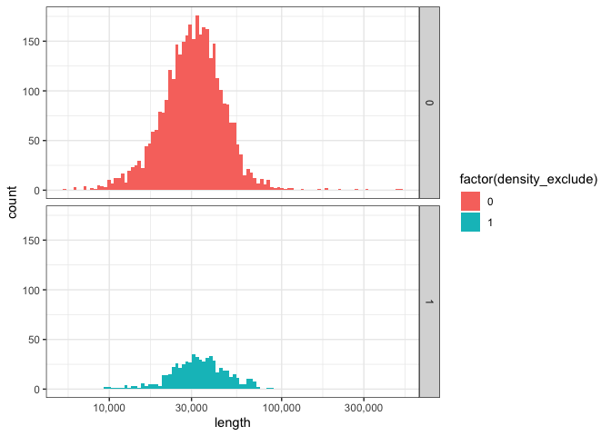

```r
# Log version

ggplot(subset, aes(x = length, fill = factor(density_exclude))) +
  geom_histogram(bins = 100) +
  facet_grid(density_exclude~.) +
  scale_x_log10(labels = comma) +
  theme_bw()
```

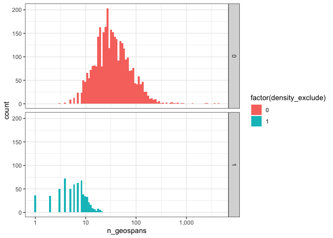

```r
ggplot(subset, aes(x = n_geospans, fill = factor(density_exclude))) +
  geom_histogram(bins = 100) +
  facet_grid(density_exclude~.) +
  scale_x_log10(labels = comma) +
  theme_bw()
```

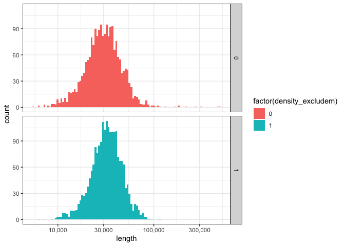

```r
ggplot(subset, aes(x = length, fill = factor(density_excludem))) +
  geom_histogram(bins = 100) +
  facet_grid(density_excludem~.) +
  scale_x_log10(labels = comma) +
  theme_bw()
```

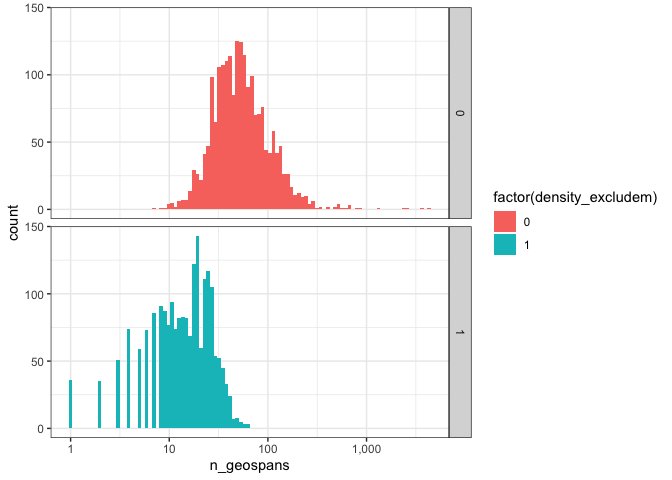

```r
ggplot(subset, aes(x = n_geospans, fill = factor(density_excludem))) +
  geom_histogram(bins = 100) +
  facet_grid(density_excludem~.) +
  scale_x_log10(labels = comma) +
  theme_bw()
```

We will exclude articles which are more than one standard deviation below the mean of log density.

## Summary

We should use documents which

- match this set of search terms;
- have a `<body>` tag;
- are a `"research-article"`.

We could also consider including `"review-article"` and `"brief-report"` types, but those seem fairly uncommon.